# Actividad3

Pedro Oliva Nacarino

2026-01-05

# 1 Metodología

En la presente actividad, el objetivo es aplicar los conceptos de bioestadística y análisis multivariante a un conjunto de datos de expresión génica en 59 individuos de la población Los Simpson. Para ello, se han seguido los siguientes pasos metodológicos: en primer lugar, se realizó la carga y limpieza del dataset, asegurando la ausencia de valores faltantes en las variables génicas seleccionadas. A continuación, se evaluó la normalidad de cada gen mediante el test de Shapiro-Wilk, lo que permitió decidir el uso de métodos estadísticos no paramétricos. Posteriormente, se llevó a cabo un análisis de componentes principales (PCA) para explorar la estructura de la variabilidad genética, extrayendo y visualizando los scores y la varianza explicada por los principales componentes. Se aplicaron técnicas de agrupamiento (clustering k-means) tanto a los genes como a los individuos, y se representaron gráficamente los patrones de agrupamiento y las contribuciones de cada variable. Además, se calcularon matrices de correlación de Spearman y se construyeron heatmaps para identificar patrones de coexpresión. Finalmente, se elaboraron tablas descriptivas por terciles de los componentes principales y se desarrollaron modelos de regresión logística para investigar asociaciones entre la expresión génica y variables clínicas o fenotípicas.

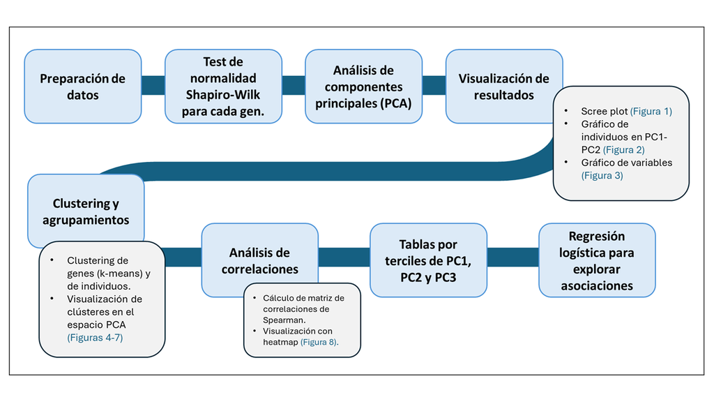

## 1.1 Paso 1. Cargar la base de datos, las librerías y limpieza

Se cargan las librerías necesarias para manipulación, análisis y visualización de datos. A continuación, se importa el archivo original con los datos completos y se crea un objeto de trabajo principal (**datos**).

Se seleccionan las variables génicas de interés y se cuantifican los valores faltantes (NA) en estas columnas. Para garantizar la robustez del análisis, se eliminan todas las filas que presentan datos ausentes en cualquiera de los genes. Finalmente, se verifica el tamaño del conjunto de datos limpio y se guarda una versión depurada en un nuevo archivo, que vamos a utilizar para los análisis posteriores.

```r
# Cargar librerías necesarias
library(tidyverse)
library(pheatmap)
library(FactoMineR)
library(factoextra)
library(gtsummary)
library(flextable)
library(officer)
library(patchwork)

# Importar la base de datos
Base_de_datos_Los_Simpson_completa <- read_csv("Base de datos Los Simpson completa.csv")

# Crear objeto principal para acortar el nombre y facilitar la escritura del código
datos <- Base_de_datos_Los_Simpson_completa

# Visualizar la base de datos
View(Base_de_datos_Los_Simpson_completa)


# Explorar estructura y resumen (lo dejo con #, activar si se prefiere explorar)
#str(datos)
#summary(datos)

# Comprobar nombres de columnas para confirmar rango de genes (lo dejo con #, activar si se prefiere explorar)
#names(datos)

# Seleccionar variables génicas (ADCY3 a UHMK1)
genes <- datos %>% select(ADCY3:UHMK1)

# Contar valores faltantes en genes
cat("Número total de valores NA en genes:", sum(is.na(genes)), "\n")
```

```
## Número total de valores NA en genes: 0
```

```r
# Eliminar filas con NA en genes
datos <- datos[complete.cases(genes), ]

# Confirmar dimensiones después de limpieza
cat("Dimensiones del dataset limpio:", dim(datos), "\n")
```

```
## Dimensiones del dataset limpio: 59 97
```

```r
# Guardar versión limpia
write_csv(datos, "Base_de_datos_Los_Simpson_limpia.csv")
```

## 1.2 Paso 2. Test de normalidad Shapiro-Wilk para las variables génicas

Ninguna de las 37 variables génicas sigue una distribución normal (todas tienen p < 0.05). Por este motivo para relizar el análisis descriptivo tenemos que usar la mediana y el rango intercuartílico en lugar de la media y la desviación estándar. Para las correlaciones, usar métodos no paramétricos (Spearman). Para PCA, esto no supone un problema porque se basa en correlaciones y escalado.

```r
# Aplicar el test Shapiro-Wilk a cada variable génica (ADCY3 a UHMK1)
pvalores <- sapply(datos %>% select(ADCY3:UHMK1), function(x) shapiro.test(x)$p.value)

# Convertir los resultados en un data frame ordenado
tabla_normalidad <- data.frame(
  Gen = names(pvalores),
  p_value = round(pvalores, 4)
)

# Mostrar la tabla
print(tabla_normalidad)
```

```
##               Gen p_value
## ADCY3       ADCY3   0e+00
## AGRP         AGRP   0e+00
## ANKRD27   ANKRD27   0e+00
## ANO4         ANO4   0e+00
## BDNF         BDNF   0e+00
## CADM1       CADM1   0e+00
## CADM2       CADM2   0e+00
## CALCR       CALCR   0e+00
## CNR1         CNR1   0e+00
## CREBRF     CREBRF   0e+00
## DPP9         DPP9   0e+00
## FTO           FTO   0e+00
## GIPR         GIPR   0e+00
## GPR151     GPR151   2e-04
## GPR75       GPR75   0e+00
## KIAA0586 KIAA0586   0e+00
## KIAA1109 KIAA1109   1e-04
## KSR2         KSR2   0e+00
## LEP           LEP   0e+00
## LEPR         LEPR   0e+00
## MC4R         MC4R   0e+00
## MRAP2       MRAP2   0e+00
## NRP1         NRP1   0e+00
## NRP2         NRP2   0e+00
## NTRK2       NTRK2   0e+00
## PCSK1       PCSK1   0e+00
## PDE3B       PDE3B   0e+00
## PHIP         PHIP   0e+00
## POMC         POMC   0e+00
## PPARG       PPARG   0e+00
## ROBO1       ROBO1   0e+00
## SH2B1       SH2B1   0e+00
## SIM1         SIM1   0e+00
## SPARC       SPARC   0e+00
## TMEM18     TMEM18   0e+00
## UBR2         UBR2   0e+00
## UHMK1       UHMK1   0e+00
```

```r
# Si p_value < 0.05 -> la variable NO sigue distribución normal
# Si p_value >= 0.05 -> la variable sigue distribución normal

# Contar cuántas variables son normales y cuántas no
normales <- sum(tabla_normalidad$p_value >= 0.05)
no_normales <- sum(tabla_normalidad$p_value < 0.05)

cat("Variables con distribución normal:", normales, "\n")
```

```
## Variables con distribución normal: 0
```

```r
cat("Variables sin distribución normal:", no_normales, "\n")
```

```
## Variables sin distribución normal: 37
```

# 2 Resultados

## 2.1 Paso 3: Análisis de componentes principales

En este bloque se realiza el análisis de componentes principales (PCA) sobre la expresión génica, asegurando previamente que no existan columnas antiguas de componentes principales en el conjunto de datos, lo que previene errores por duplicidad en ejecuciones sucesivas del script.

Se seleccionan las variables génicas y se aplica el PCA, estandarizando los datos. Posteriormente, se extraen los scores de los componentes principales y se añaden al dataframe principal para facilitar análisis posteriores.

Para la interpretación visual de los resultados, se generan y guardan en formato PNG tres gráficos clave: el **scree plot** (Figura 1), la distribución de los individuos en el espacio de las dos primeras componentes principales (Figura 2) y la contribución de cada gen a las componentes principales (Figura 3). Estas visualizaciones permiten identificar patrones de variabilidad y agrupamiento en la expresión génica de la muestra.

**Figura 1** muestra que la primera componente principal (Dimensión 1) explica el **12,5 %** de la varianza total, mientras que la segunda componente (Dimensión 2) aporta un **8,6 %**. Aunque cada componente individual explica una proporción moderada, en conjunto permiten visualizar los patrones principales de variabilidad en los datos. El resto de componentes contribuye con porcentajes menores, lo que indica que la información está distribuida entre varias dimensiones.

En **Figura 2**, la representación de los individuos en el plano definido por PC1 y PC2 revela cierta dispersión y posibles agrupamientos, lo que sugiere diferencias en perfiles de expresión génica entre subconjuntos de la muestra. Este patrón puede estar asociado a condiciones experimentales o características biológicas específicas.

Por último, **Figura 3** indica que algunos genes presentan una alta contribución a PC1 y PC2, destacando su papel en la variabilidad global. Las variables más alejadas del centro son las que más influyen en la separación de los individuos, lo que permite priorizar genes relevantes para análisis posteriores.

```r
# Eliminar columnas previas de componentes principales
# si existen (si ejecutamos el script varias veces en la misma sesión de R, se pueden acumular columnas de componentes principales antiguas y nuevas, lo que puede causar errores o confusión.)

datos <- datos %>% select(-matches("^PC[0-9]+$"))

# Realizar el PCA con las variables génicas
pca <- PCA(datos %>% select(ADCY3:UHMK1), scale.unit = TRUE, graph = FALSE)

# Extraer los scores de los componentes principales
scores <- as.data.frame(pca$ind$coord)
colnames(scores) <- paste0("PC", seq_len(ncol(scores)))

# Añadir los scores al dataframe principal
datos <- cbind(datos, scores)
```

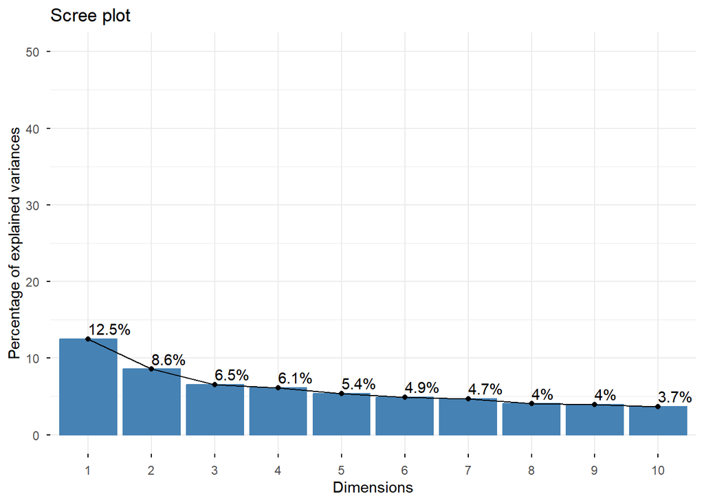

```r
# Visualización: Scree plot (varianza explicada)
grafico_eig <- fviz_eig(pca, addlabels = TRUE, ylim = c(0, 50))
ggsave("scree_plot.png", plot = grafico_eig, width = 8, height = 6, dpi = 300, units = "in")

grafico_eig
```

**Figura 1.** Scree plot del análisis de componentes principales (PCA), mostrando la proporción de varianza explicada por cada componente.

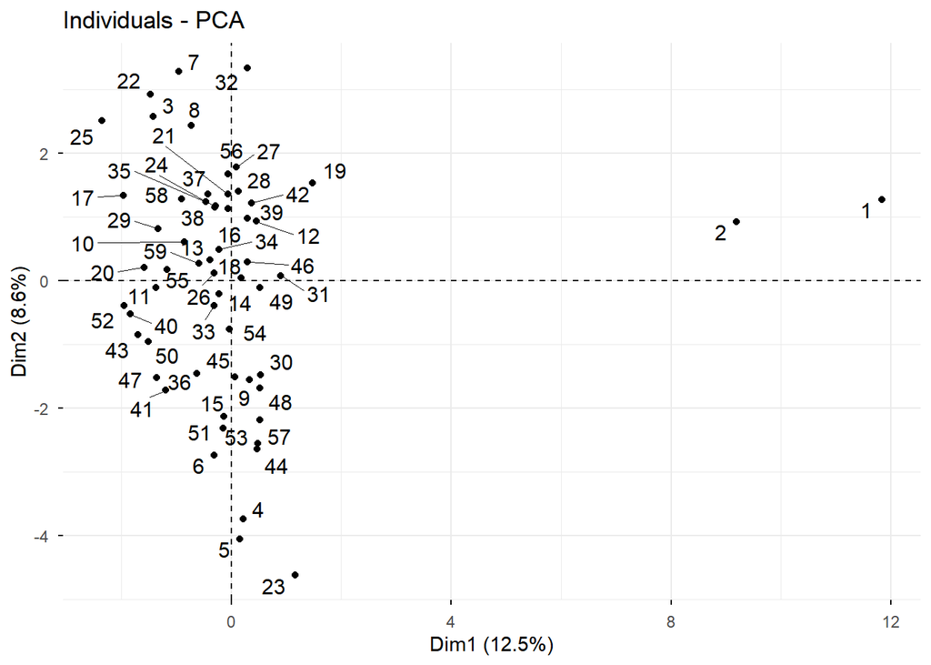

```r
# Visualización de individuos en las dos primeras componentes
grafico_ind <- fviz_pca_ind(pca, repel = TRUE)
ggsave("pca_individuos.png", plot = grafico_ind, width = 8, height = 6, dpi = 300, units = "in")

grafico_ind
```

**Figura 2.** Gráfico de individuos en el espacio definido por los dos primeros componentes principales (PC1 y PC2), indicando agrupamientos y dispersión.

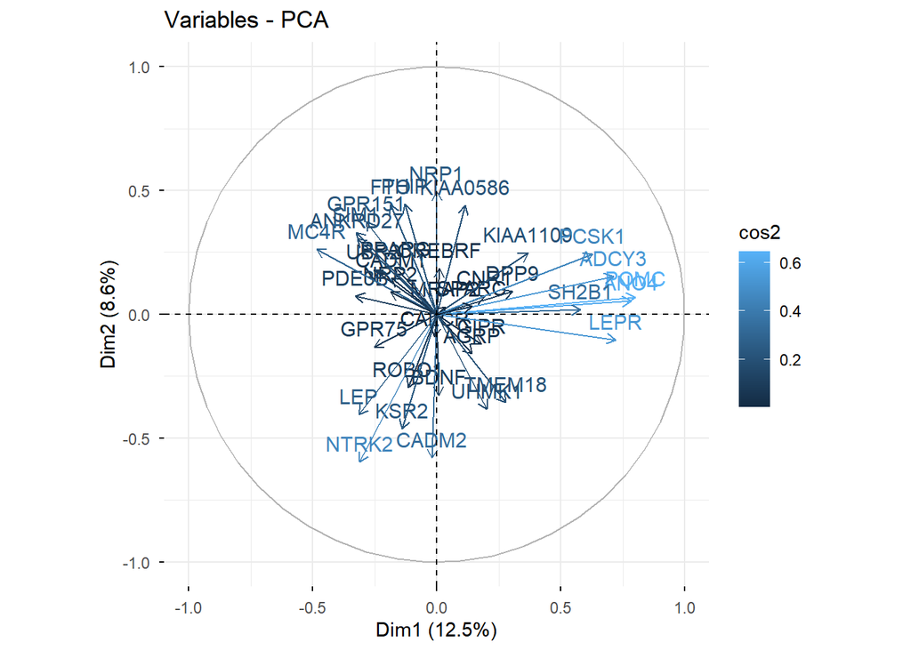

```r
# Visualización de variables (genes)
grafico_var <- fviz_pca_var(pca, col.var = "cos2")
ggsave("pca_variables.png", plot = grafico_var, width = 8, height = 6, dpi = 300, units = "in")

grafico_var
```

**Figura 3.** Gráfico de variables del PCA, representando la correlación de cada variable con los componentes principales y su contribución al modelo.

### 2.1.1 Tabla PCA componentes y R2

Este bloque extrae la varianza explicada por cada componente principal tras realizar el PCA. Se convierte la matriz de eigenvalores (pca$eig) en un *data frame* y se renombran las columnas para mayor claridad: eigenvalor, porcentaje de varianza explicada y porcentaje acumulado. Se añade una columna identificando cada componente principal (PC1, PC2, etc.). Finalmente, se seleccionan y muestran en pantalla los porcentajes de varianza explicada por cada componente, lo que permite identificar cuánta información aporta cada uno al modelo y facilita la interpretación de los resultados del análisis multivariante.

```r
# Extraer la varianza explicada por cada componente
pca_var <- as.data.frame(pca$eig)
colnames(pca_var) <- c("Eigenvalue", "Porcentaje_varianza", "Porcentaje_acumulado")
pca_var$Componente <- paste0("PC", seq_len(nrow(pca_var)))
tabla_R2 <- pca_var[, c("Componente", "Porcentaje_varianza")]
print(tabla_R2)
```

```
##         Componente Porcentaje_varianza
## comp 1         PC1          12.4817836
## comp 2         PC2           8.5616785
## comp 3         PC3           6.5262221
## comp 4         PC4           6.1315584
## comp 5         PC5           5.3557322
## comp 6         PC6           4.8882799
## comp 7         PC7           4.7170909
## comp 8         PC8           4.0408927
## comp 9         PC9           3.9652172
## comp 10       PC10           3.6894817
## comp 11       PC11           3.3649117
## comp 12       PC12           3.2416488
## comp 13       PC13           2.9478378
## comp 14       PC14           2.8756600
## comp 15       PC15           2.5016701
## comp 16       PC16           2.4258253
## comp 17       PC17           2.3491687
## comp 18       PC18           2.1920478
## comp 19       PC19           2.0069710
## comp 20       PC20           1.8552478
## comp 21       PC21           1.7718594
## comp 22       PC22           1.5904981
## comp 23       PC23           1.4337045
## comp 24       PC24           1.3030016
## comp 25       PC25           1.1595593
## comp 26       PC26           1.0457028
## comp 27       PC27           0.8951565
## comp 28       PC28           0.8240486
## comp 29       PC29           0.7389995
## comp 30       PC30           0.6496958
## comp 31       PC31           0.6147459
## comp 32       PC32           0.5159022
## comp 33       PC33           0.3987867
## comp 34       PC34           0.3215975
## comp 35       PC35           0.2488986
## comp 36       PC36           0.2250591
## comp 37       PC37           0.1438577
```

**Tabla 2.** Contribución porcentual de cada componente principal a la varianza total.

### 2.1.2 Tabla PCA cargas

Este bloque extrae las cargas (coordenadas) de cada gen en los componentes principales obtenidos tras el PCA. Primero, convierte la matriz de coordenadas en un data frame y añade una columna con el nombre de cada gen. Luego, selecciona únicamente las columnas correspondientes a los dos primeros componentes principales (PC1 y PC2), facilitando así la interpretación de la contribución de cada gen a estos ejes. Finalmente, la tabla resultante se visualiza en consola y se exporta en formato Word, permitiendo su inclusión directa en informes o presentaciones.

```r
# Extraer las cargas (coordenadas) de los genes en los componentes principales
tabla_cargas <- as.data.frame(pca$var$coord)
tabla_cargas$Variable <- rownames(tabla_cargas)

# Selecciona solo las columnas de los dos primeros componentes
tabla_cargas_final <- tabla_cargas[, c("Variable", "Dim.1", "Dim.2")]
colnames(tabla_cargas_final) <- c("Variable", "PC1", "PC2")

# Visualizar la tabla en consola
print(tabla_cargas_final)
```

```
##          Variable           PC1         PC2
## ADCY3       ADCY3  0.7119526892  0.15359180
## AGRP         AGRP  0.1422346975 -0.16008270
## ANKRD27   ANKRD27 -0.3204310408  0.30628766
## ANO4         ANO4  0.7829478175  0.05421525
## BDNF         BDNF  0.0082568126 -0.32708718
## CADM1       CADM1 -0.1831853054  0.14840722
## CADM2       CADM2 -0.0201860643 -0.58105666
## CALCR       CALCR -0.0090326727 -0.08992664
## CNR1         CNR1  0.1926870891  0.07323999
## CREBRF     CREBRF  0.0117420180  0.18537155
## DPP9         DPP9  0.3056132282  0.09199802
## FTO           FTO -0.1853083565  0.44280569
## GIPR         GIPR  0.1786476728 -0.12183652
## GPR151     GPR151 -0.2841109032  0.37425181
## GPR75       GPR75 -0.2522906751 -0.13222832
## KIAA0586 KIAA0586  0.1151605269  0.44004797
## KIAA1109 KIAA1109  0.3671798972  0.24782514
## KSR2         KSR2 -0.1409602112 -0.46254706
## LEP           LEP -0.3157334370 -0.40523135
## LEPR         LEPR  0.7208890036 -0.10342607
## MC4R         MC4R -0.4834494961  0.26095753
## MRAP2       MRAP2  0.0355872376  0.02869782
## NRP1         NRP1  0.0002499731  0.49523852
## NRP2         NRP2 -0.1875359077  0.08987917
## NTRK2       NTRK2 -0.3116235095 -0.59697250
## PCSK1       PCSK1  0.6272870705  0.24292548
## PDE3B       PDE3B -0.3280131453  0.07445819
## PHIP         PHIP -0.1280317142  0.44473819
## POMC         POMC  0.8009267873  0.06947457
## PPARG       PPARG -0.1673606024  0.19199976
## ROBO1       ROBO1 -0.1157837758 -0.29567434
## SH2B1       SH2B1  0.5791160627  0.01935722
## SIM1         SIM1 -0.3252065198  0.33150937
## SPARC       SPARC  0.1421604334  0.03318966
## TMEM18     TMEM18  0.2794757145 -0.35601888
## UBR2         UBR2 -0.2548320872  0.18007884
## UHMK1       UHMK1  0.2017726411 -0.38196356
```

```r
# Exportar la tabla de cargas a Word
flextable(tabla_cargas_final) %>%
  save_as_docx(path = "tabla_cargas_PCA.docx")
```

**Tabla 3.** Cargas factoriales de las variables en los dos primeros componentes principales, destacando aquellas con mayor influencia en PC1 y PC2.

## 2.2 Paso 4: Visualizaciones avanzadas y clustering.

Se analizan los patrones de agrupamiento tanto de genes como de individuos en el espacio definido por los dos primeros componentes principales (PC1 y PC2). Se aplica el algoritmo k-means para realizar el clustering de los genes, identificando tres grupos diferenciados según su perfil de expresión. Esta visualización permite observar la distribución de los genes en el espacio PCA y su contribución relativa a cada componente principal.

Figura 4. Mapa PCA con los genes coloreados según los tres clústeres obtenidos mediante k-means. Se aprecia que los grupos presentan posiciones claramente diferenciadas, lo que indica perfiles de expresión distintos. Los genes más alejados del centro son los que más contribuyen a la variabilidad global.

Figura 7. Agrupamiento de individuos en el plano PCA, mostrando los clústeres identificados mediante k-means y su posible relación con características genéticas y clínicas. Estos agrupamientos aportan información adicional sobre la estructura interna de la muestra y posibles correlaciones con variables fenotípicas.

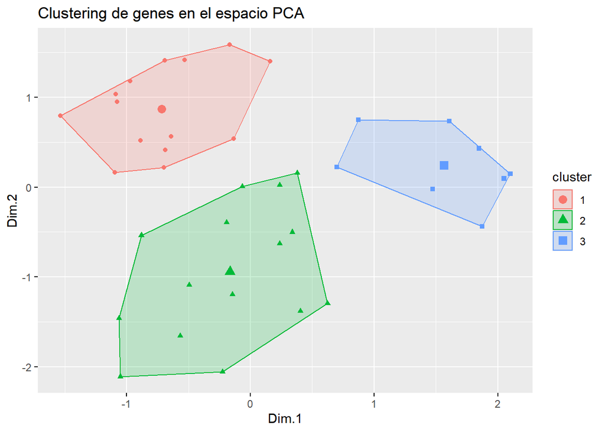

```r
# --- Clustering de variables (genes) en el espacio PCA

# Definir coordenadas de las variables (genes) en las dos primeras dimensiones
var_coord <- pca$var$coord[, 1:2]

# Aplicar clustering k-means a los genes
set.seed(3)
clust_var <- kmeans(var_coord, centers = 3, nstart = 25)

# Visualización del clustering de genes
grafico_cluster_genes <- fviz_cluster(list(data = var_coord, cluster = clust_var$cluster),
                                      geom = "point",
                                      main = "Clustering de genes en el espacio PCA")
# Exportar en PNG
ggsave("clustering_genes.png", plot = grafico_cluster_genes, width = 8, height = 6, dpi = 300, units = "in")

grafico_cluster_genes
```

**Figura 4.** Mapa PCA con clustering de variables (genes). Representa las variables proyectadas en el espacio definido por los dos primeros componentes principales (PC1 y PC2). Los grupos se indican mediante colores y elipses que reflejan la proximidad y similitud entre genes.

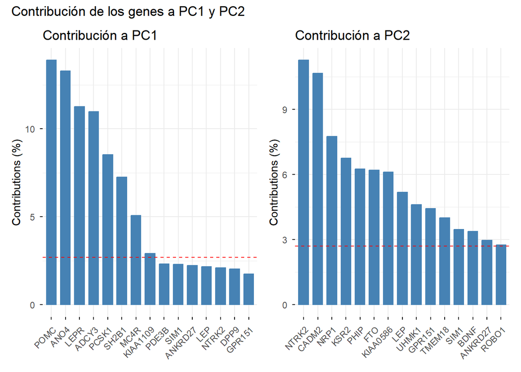

```r
# --- Visualización de contribuciones de los genes a PC1 y PC2 ---
grafico_contrib_PC1 <- fviz_contrib(pca, choice = "var", axes = 1, top = 15) + ggtitle("Contribución a PC1")
ggsave("contrib_PC1.png", plot = grafico_contrib_PC1, width = 8, height = 6, dpi = 300, units = "in")

grafico_contrib_PC2 <- fviz_contrib(pca, choice = "var", axes = 2, top = 15) + ggtitle("Contribución a PC2")
ggsave("contrib_PC2.png", plot = grafico_contrib_PC2, width = 8, height = 6, dpi = 300, units = "in")


# Gráfico compuesto con patchwork
grafico_patchwork <- grafico_contrib_PC1 + grafico_contrib_PC2 +
  plot_layout(ncol = 2) +
  plot_annotation(title = "Contribución de los genes a PC1 y PC2")

# Guardar el gráfico compuesto
ggsave("contribuciones_patchwork.png", plot = grafico_patchwork, width = 16, height = 6, dpi = 300, units = "in")

# Mostrar en pantalla
grafico_patchwork
```

**Figura 5.** Gráficos de contribución de variables para PC1 (A) y PC2 (B). Identificación de los genes que más aportan a la variabilidad total del modelo. Se presentan los 15 genes con mayor peso estadístico en cada eje. Las variables por encima de la línea roja son las que definen la estructura de los datos en el análisis de componentes principales.

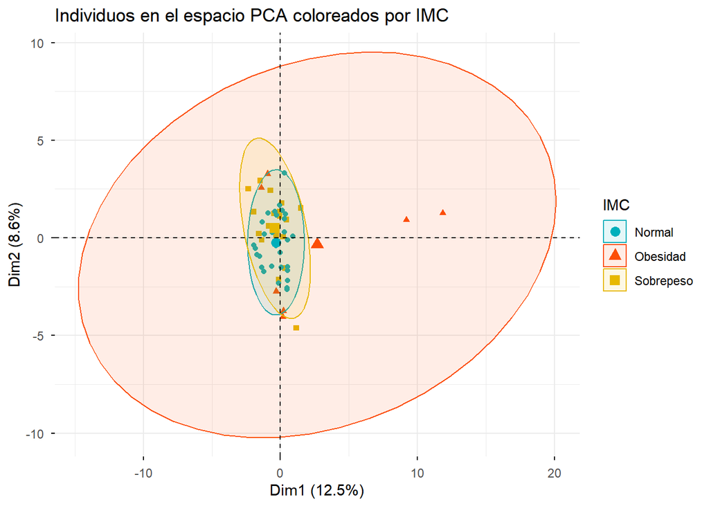

```r
# --- Creación de variable categórica de IMC ---
datos <- datos %>%
  mutate(IMC_cat = case_when(
    imc_kg_m2 < 25 ~ "Normal",
    imc_kg_m2 >= 25 & imc_kg_m2 < 30 ~ "Sobrepeso",
    imc_kg_m2 >= 30 ~ "Obesidad"
  ))
# --- Visualización de individuos coloreados por categoría de IMC ---
grafico_ind_IMC <- fviz_pca_ind(pca,
                                geom.ind = "point",
                                col.ind = datos$IMC_cat,
                                palette = c("Normal" = "#00AFBB", "Sobrepeso" = "#E7B800", "Obesidad" = "#FC4E07"),
                                addEllipses = TRUE,
                                legend.title = "IMC",
                                title = "Individuos en el espacio PCA coloreados por IMC")
ggsave("individuos_IMC.png", plot = grafico_ind_IMC, width = 8, height = 6, dpi = 300, units = "in")

grafico_ind_IMC
```

**Figura 6.** Representación de los individuos en el espacio PCA (PC1 y PC2), coloreados según la categoría de IMC (normal, sobrepeso y obesidad).

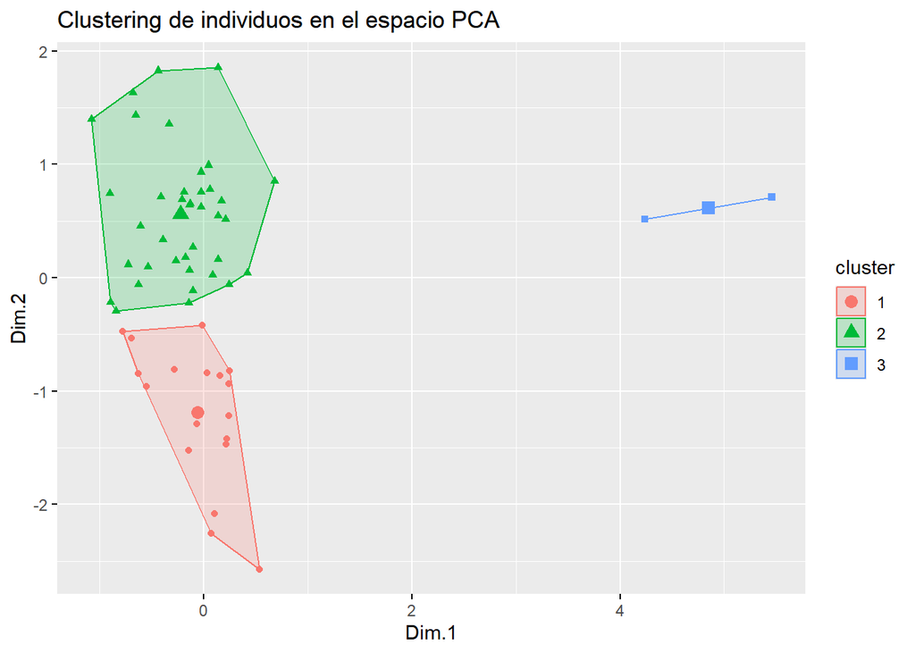

```r
# --- Clustering de individuos en el espacio PCA ---
ind_coord <- pca$ind$coord[, 1:2]
set.seed(3)
clust_ind <- kmeans(ind_coord, centers = 3, nstart = 25)

grafico_cluster_ind <- fviz_cluster(list(data = ind_coord, cluster = clust_ind$cluster),
                                    geom = "point",
                                    main = "Clustering de individuos en el espacio PCA")
ggsave("clustering_individuos.png", plot = grafico_cluster_ind, width = 8, height = 6, dpi = 300, units = "in")

grafico_cluster_ind
```

**Figura 7.**Agrupamiento de individuos en el plano PCA, mostrando los clústeres identificados mediante k-means y su posible relación con características genéticas y clínicas.

## 2.3 Paso 5: Heatmap de correlaciones

Se calcula la matriz de correlaciones de Spearman entre la expresión de los genes y los componentes principales obtenidos por PCA. Primero, se seleccionan únicamente las columnas numéricas correspondientes a los genes y a los componentes principales. Se calcula la matriz de correlaciones utilizando el método de Spearman, adecuado para variables que no siguen una distribución normal.

Para asegurar la calidad de la visualización, se eliminan filas y columnas con valores no finitos (NA, NaN o Inf). Si la matriz resultante contiene suficientes datos, se genera un heatmap que permite identificar visualmente asociaciones específicas entre genes y componentes principales, facilitando la interpretación de patrones de coexpresión y relaciones biológicas relevantes. Si no hay suficientes datos válidos, se informa al usuario.

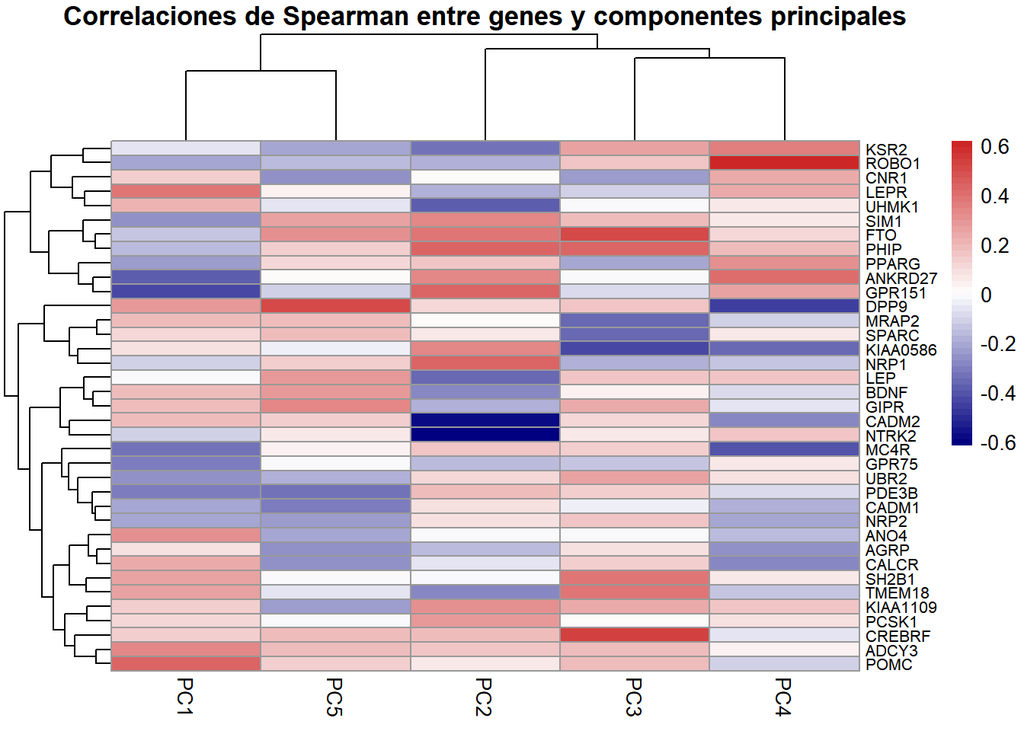

```r
genes <- datos %>% select(ADCY3:UHMK1) %>% select(where(is.numeric))
pcs <- datos %>% select(matches("^PC[0-9]+$"))  # Solo PC1, PC2, etc.
cor_matrix <- cor(genes, pcs, method = "spearman")
cor_matrix <- cor_matrix[
  apply(cor_matrix, 1, function(x) all(is.finite(x))),
  apply(cor_matrix, 2, function(x) all(is.finite(x)))
]

pheatmap(
  cor_matrix,
  main = "Correlaciones de Spearman entre genes y componentes principales",
  color = colorRampPalette(c("navy", "white", "firebrick3"))(50),
  fontsize_row = 8,
  fontsize_col = 10
)
```

```r
# Guardar como PNG
pheatmap(
  cor_matrix,
  main = "Correlaciones de Spearman entre genes y componentes principales",
  color = colorRampPalette(c("navy", "white", "firebrick3"))(50),
  fontsize_row = 8,
  fontsize_col = 10,
  filename = "heatmap_correlaciones.png",
  width = 8, height = 6
)
```

```r
# Guardar como PNG
pheatmap(
  cor_matrix,
  main = "Correlaciones de Spearman entre genes y componentes principales",
  color = colorRampPalette(c("navy", "white", "firebrick3"))(50),
  fontsize_row = 8,
  fontsize_col = 10,
  filename = "heatmap_correlaciones.png",
  width = 8, height = 6
)
```

## 2.4 Paso 6 - Tabla descriptiva por terciles de PC1, PC2 y PC3

Se categorizan los valores de los tres primeros componentes principales (PC1, PC2 y PC3) en terciles, dividiendo la distribución de cada componente en tres grupos de igual tamaño: bajo (T1), medio (T2) y alto (T3). Esta transformación facilita la comparación de características clínicas y genéticas entre grupos y permite realizar análisis descriptivos y modelos estadísticos ajustados por niveles de expresión, en lugar de valores continuos.

```r
# 1. Crear terciles para PC1, PC2 y PC3
datos <- datos %>%
  mutate(
    PC1_t = cut(PC1, breaks = quantile(PC1, probs = c(0, 1/3, 2/3, 1)), include.lowest = TRUE, labels = c("T1", "T2", "T3")),
    PC2_t = cut(PC2, breaks = quantile(PC2, probs = c(0, 1/3, 2/3, 1)), include.lowest = TRUE, labels = c("T1", "T2", "T3")),
    PC3_t = cut(PC3, breaks = quantile(PC3, probs = c(0, 1/3, 2/3, 1)), include.lowest = TRUE, labels = c("T1", "T2", "T3"))
  )
```

### 2.4.1 Tabla descriptiva por terciles de PC1:

```r
# 2. Tabla descriptiva por terciles de PC1
tabla_desc_PC1 <- datos %>%
  select(PC1_t, imc_kg_m2, edad_anios, ADCY3:UHMK1) %>%
  tbl_summary(
    by = PC1_t,
    statistic = all_continuous() ~ "{median} [{p25}, {p75}]",
    digits = all_continuous() ~ 2
  ) %>%
  add_p(test = all_continuous() ~ "kruskal.test") %>%
  bold_labels()


# 3. Exportar la tabla a Word
as_flex_table(tabla_desc_PC1) %>%
  save_as_docx(path = "tabla_descriptiva_PC1.docx")


tabla_desc_PC1 %>% as_gt()
```

| **Characteristic** | **T1** N = 20<sup>1</sup> | **T2** N = 19<sup>1</sup> | **T3** N = 20<sup>1</sup> | **p-value**<sup>2</sup> |
| --- | --- | --- | --- | --- |
| imc_kg_m2 | 24.03 [20.84, 27.52] | 24.84 [23.15, 26.83] | 24.59 [21.78, 28.67] | 0.8 |
| edad_anios | 41.00 [23.50, 47.50] | 40.00 [35.00, 45.00] | 40.00 [36.50, 50.00] | >0.9 |
| ADCY3 |  |  |  | 0.2 |
| -1.07000866229003 | 5 (25%) | 2 (11%) | 2 (10%) |  |
| -0.757299597062074 | 7 (35%) | 5 (26%) | 4 (20%) |  |
| -0.54001209141997 | 5 (25%) | 3 (16%) | 3 (15%) |  |
| -0.189344792890751 | 1 (5.0%) | 0 (0%) | 0 (0%) |  |
| -0.170453728921722 | 2 (10%) | 3 (16%) | 6 (30%) |  |
| -0.170453728921708 | 0 (0%) | 6 (32%) | 3 (15%) |  |
| 0.858006377459794 | 0 (0%) | 0 (0%) | 1 (5.0%) |  |
| 2.03956622404642 | 0 (0%) | 0 (0%) | 1 (5.0%) |  |
| AGRP |  |  |  | 0.6 |
| -2.33749576135416 | 2 (10%) | 3 (16%) | 1 (5.0%) |  |
| -0.243746366121897 | 4 (20%) | 2 (11%) | 5 (25%) |  |
| 0.213196657776381 | 5 (25%) | 8 (42%) | 4 (20%) |  |
| 0.232861852103368 | 0 (0%) | 0 (0%) | 1 (5.0%) |  |
| 0.252526411334765 | 2 (10%) | 3 (16%) | 2 (10%) |  |
| 0.355286460377783 | 2 (10%) | 0 (0%) | 0 (0%) |  |
| 0.662208620526537 | 1 (5.0%) | 0 (0%) | 3 (15%) |  |
| 0.865162125357232 | 4 (20%) | 3 (16%) | 4 (20%) |  |
| ANKRD27 |  |  |  | 0.076 |
| -0.988953614380515 | 0 (0%) | 0 (0%) | 1 (5.0%) |  |
| -0.786156009114048 | 0 (0%) | 0 (0%) | 1 (5.0%) |  |
| -0.419520727505715 | 0 (0%) | 4 (21%) | 2 (10%) |  |
| -0.353192031610196 | 4 (20%) | 4 (21%) | 7 (35%) |  |
| -0.180641486294449 | 5 (25%) | 2 (11%) | 4 (20%) |  |
| -0.179652812018896 | 0 (0%) | 0 (0%) | 1 (5.0%) |  |
| 0.817776393693593 | 7 (35%) | 2 (11%) | 3 (15%) |  |
| 2.09034028723035 | 4 (20%) | 7 (37%) | 1 (5.0%) |  |
| ANO4 |  |  |  | 0.12 |

[output cut: 304 more lines]

<sup>1</sup> Median [Q1, Q3]; n (%)  
<sup>2</sup> Kruskal-Wallis rank sum test; Fisher’s exact test

### 2.4.2 Tabla descriptiva por terciles de PC2:

```r
tabla_desc_PC2 <- datos %>%
  select(PC2_t, imc_kg_m2, edad_anios, ADCY3:UHMK1) %>%
  tbl_summary(
    by = PC2_t,
    statistic = all_continuous() ~ "{median} [{p25}, {p75}]",
    digits = all_continuous() ~ 2
  ) %>%
  add_p(test = all_continuous() ~ "kruskal.test") %>%
  bold_labels()

# Exportar a Word
as_flex_table(tabla_desc_PC2) %>%
  save_as_docx(path = "tabla_descriptiva_PC2.docx")

tabla_desc_PC2 %>% as_gt()
```

| **Characteristic** | **T1** N = 20<sup>1</sup> | **T2** N = 19<sup>1</sup> | **T3** N = 20<sup>1</sup> | **p-value**<sup>2</sup> |
| --- | --- | --- | --- | --- |
| imc_kg_m2 | 22.29 [20.58, 26.53] | 24.69 [21.51, 27.76] | 25.61 [23.34, 26.57] | 0.2 |
| edad_anios | 40.00 [25.00, 44.50] | 42.00 [20.00, 50.00] | 42.50 [37.00, 50.00] | 0.5 |
| ADCY3 |  |  |  | 0.9 |
| -1.07000866229003 | 4 (20%) | 3 (16%) | 2 (10%) |  |
| -0.757299597062074 | 5 (25%) | 6 (32%) | 5 (25%) |  |
| -0.54001209141997 | 5 (25%) | 4 (21%) | 2 (10%) |  |
| -0.189344792890751 | 0 (0%) | 0 (0%) | 1 (5.0%) |  |
| -0.170453728921722 | 3 (15%) | 2 (11%) | 6 (30%) |  |
| -0.170453728921708 | 3 (15%) | 3 (16%) | 3 (15%) |  |
| 0.858006377459794 | 0 (0%) | 0 (0%) | 1 (5.0%) |  |
| 2.03956622404642 | 0 (0%) | 1 (5.3%) | 0 (0%) |  |
| AGRP |  |  |  | 0.2 |
| -2.33749576135416 | 2 (10%) | 1 (5.3%) | 3 (15%) |  |
| -0.243746366121897 | 3 (15%) | 3 (16%) | 5 (25%) |  |
| 0.213196657776381 | 5 (25%) | 7 (37%) | 5 (25%) |  |
| 0.232861852103368 | 1 (5.0%) | 0 (0%) | 0 (0%) |  |
| 0.252526411334765 | 0 (0%) | 5 (26%) | 2 (10%) |  |
| 0.355286460377783 | 1 (5.0%) | 0 (0%) | 1 (5.0%) |  |
| 0.662208620526537 | 4 (20%) | 0 (0%) | 0 (0%) |  |
| 0.865162125357232 | 4 (20%) | 3 (16%) | 4 (20%) |  |
| ANKRD27 |  |  |  | 0.031 |
| -0.988953614380515 | 0 (0%) | 0 (0%) | 1 (5.0%) |  |
| -0.786156009114048 | 0 (0%) | 1 (5.3%) | 0 (0%) |  |
| -0.419520727505715 | 3 (15%) | 2 (11%) | 1 (5.0%) |  |
| -0.353192031610196 | 10 (50%) | 3 (16%) | 2 (10%) |  |
| -0.180641486294449 | 3 (15%) | 2 (11%) | 6 (30%) |  |
| -0.179652812018896 | 1 (5.0%) | 0 (0%) | 0 (0%) |  |
| 0.817776393693593 | 1 (5.0%) | 7 (37%) | 4 (20%) |  |
| 2.09034028723035 | 2 (10%) | 4 (21%) | 6 (30%) |  |
| ANO4 |  |  |  | 0.5 |

[output cut: 304 more lines]

<sup>1</sup> Median [Q1, Q3]; n (%)  
<sup>2</sup> Kruskal-Wallis rank sum test; Fisher’s exact test

### 2.4.3 Tabla descriptiva por terciles de PC3:

```r
tabla_desc_PC3 <- datos %>%
  select(PC3_t, imc_kg_m2, edad_anios, ADCY3:UHMK1) %>%
  tbl_summary(
    by = PC3_t,
    statistic = all_continuous() ~ "{median} [{p25}, {p75}]",
    digits = all_continuous() ~ 2
  ) %>%
  add_p(test = all_continuous() ~ "kruskal.test") %>%
  bold_labels()

# Exportar a Word
as_flex_table(tabla_desc_PC3) %>%
  save_as_docx(path = "tabla_descriptiva_PC3.docx")

tabla_desc_PC3 %>% as_gt()
```

| **Characteristic** | **T1** N = 20<sup>1</sup> | **T2** N = 19<sup>1</sup> | **T3** N = 20<sup>1</sup> | **p-value**<sup>2</sup> |
| --- | --- | --- | --- | --- |
| imc_kg_m2 | 24.59 [22.19, 26.87] | 26.12 [20.45, 28.73] | 23.85 [22.04, 26.17] | 0.7 |
| edad_anios | 41.00 [13.00, 50.00] | 40.00 [35.00, 45.00] | 40.50 [40.00, 45.00] | 0.5 |
| ADCY3 |  |  |  | 0.4 |
| -1.07000866229003 | 5 (25%) | 2 (11%) | 2 (10%) |  |
| -0.757299597062074 | 4 (20%) | 6 (32%) | 6 (30%) |  |
| -0.54001209141997 | 6 (30%) | 3 (16%) | 2 (10%) |  |
| -0.189344792890751 | 0 (0%) | 1 (5.3%) | 0 (0%) |  |
| -0.170453728921722 | 3 (15%) | 4 (21%) | 4 (20%) |  |
| -0.170453728921708 | 2 (10%) | 1 (5.3%) | 6 (30%) |  |
| 0.858006377459794 | 0 (0%) | 1 (5.3%) | 0 (0%) |  |
| 2.03956622404642 | 0 (0%) | 1 (5.3%) | 0 (0%) |  |
| AGRP |  |  |  | 0.8 |
| -2.33749576135416 | 3 (15%) | 2 (11%) | 1 (5.0%) |  |
| -0.243746366121897 | 4 (20%) | 2 (11%) | 5 (25%) |  |
| 0.213196657776381 | 7 (35%) | 5 (26%) | 5 (25%) |  |
| 0.232861852103368 | 0 (0%) | 0 (0%) | 1 (5.0%) |  |
| 0.252526411334765 | 1 (5.0%) | 4 (21%) | 2 (10%) |  |
| 0.355286460377783 | 0 (0%) | 1 (5.3%) | 1 (5.0%) |  |
| 0.662208620526537 | 0 (0%) | 2 (11%) | 2 (10%) |  |
| 0.865162125357232 | 5 (25%) | 3 (16%) | 3 (15%) |  |
| ANKRD27 |  |  |  | 0.2 |
| -0.988953614380515 | 0 (0%) | 1 (5.3%) | 0 (0%) |  |
| -0.786156009114048 | 0 (0%) | 1 (5.3%) | 0 (0%) |  |
| -0.419520727505715 | 2 (10%) | 1 (5.3%) | 3 (15%) |  |
| -0.353192031610196 | 5 (25%) | 5 (26%) | 5 (25%) |  |
| -0.180641486294449 | 4 (20%) | 2 (11%) | 5 (25%) |  |
| -0.179652812018896 | 0 (0%) | 1 (5.3%) | 0 (0%) |  |
| 0.817776393693593 | 4 (20%) | 7 (37%) | 1 (5.0%) |  |
| 2.09034028723035 | 5 (25%) | 1 (5.3%) | 6 (30%) |  |
| ANO4 |  |  |  | 0.9 |

[output cut: 304 more lines]

<sup>1</sup> Median [Q1, Q3]; n (%)  
<sup>2</sup> Kruskal-Wallis rank sum test; Fisher’s exact test

## 2.5 Paso 7.Regresión logística.

El modelo de regresión logística evaluó la asociación entre los terciles de los tres primeros componentes principales (PC1_t, PC2_t, PC3_t), la edad y el sexo, con la presencia de obesidad (IMC ≥ 30) como variable dependiente.

Ninguno de los terciles de los componentes principales mostró una asociación estadísticamente significativa con la obesidad (todos los valores p > 0,05). Por ejemplo, el tercil más alto de PC1 (T3) presentó un OR de 3,36 (IC 95%: 0,46–35,8; p = 0,3), lo que indica una tendencia no significativa hacia un mayor riesgo de obesidad en este grupo, pero con un intervalo de confianza muy amplio. Para PC2 y PC3, tampoco se observaron asociaciones significativas. Los OR para los diferentes terciles oscilaron alrededor de 1, con intervalos de confianza amplios y valores p elevados. La edad mostró un OR de 1,02 (IC 95%: 0,97–1,07; p = 0,4), lo que sugiere que, en este modelo, la edad no se asoció significativamente con la obesidad. El sexo masculino presentó un OR de 1,28 (IC 95%: 0,07–21,0; p = 0,9) en comparación con el femenino, sin alcanzar significación estadística.

```r
# Crear variable binaria de obesidad (1 = obesidad, 0 = no obesidad)
datos$obesidad <- ifelse(datos$imc_kg_m2 >= 30, 1, 0)

# Modelo de regresión logística con obesidad como variable dependiente
modelo_logistico <- glm(obesidad ~ PC1_t + PC2_t + PC3_t + edad_anios + sexo,
                       data = datos,
                       family = binomial)

# Tabla de resultados con odds ratio, IC 95% y p-valor
library(gtsummary)
tbl_regression(modelo_logistico, exponentiate = TRUE)
```

| **Characteristic** | **OR** | **95% CI** | **p-value** |
| --- | --- | --- | --- |
| PC1_t |  |  |  |
| T1 | — | — |  |
| T2 | 0.58 | 0.02, 7.48 | 0.7 |
| T3 | 3.36 | 0.46, 35.8 | 0.3 |
| PC2_t |  |  |  |
| T1 | — | — |  |
| T2 | 0.21 | 0.01, 3.85 | 0.3 |
| T3 | 1.26 | 0.12, 21.0 | 0.9 |
| PC3_t |  |  |  |
| T1 | — | — |  |
| T2 | 4.35 | 0.45, 102 | 0.2 |
| T3 | 1.02 | 0.06, 27.2 | >0.9 |
| edad_anios | 1.02 | 0.97, 1.07 | 0.4 |
| sexo |  |  |  |
| Femenino | — | — |  |
| Masculino | 1.28 | 0.07, 21.0 | 0.9 |

Abbreviations: CI = Confidence Interval, OR = Odds Ratio

```r
tbl_regression(modelo_logistico, exponentiate = TRUE) %>%
  as_flex_table() %>%
  flextable::save_as_docx(path = "tabla_regresion_logistica_obesidad.docx")
```

# 3 Interpretación

Finalmente, la regresión logística realizada para evaluar la asociación entre los terciles de los componentes principales, la edad y el sexo con la presencia de obesidad no mostró asociaciones estadísticamente significativas. Ninguno de los terciles de PC1, PC2 o PC3, ni la edad ni el sexo, se asociaron de forma significativa con la obesidad en la muestra analizada (todos los valores p > 0,05). Los intervalos de confianza amplios y la ausencia de significación estadística sugieren que, en este conjunto de datos, la variabilidad genética capturada por los componentes principales no se traduce en diferencias claras en el riesgo de obesidad, aunque no se descarta que el tamaño muestral limitado pueda influir en estos resultados. En resumen, aunque se identificaron patrones genéticos diferenciados y algunos genes concretos mostraron asociaciones relevantes con los componentes principales, estos patrones no se reflejaron en diferencias significativas en la presencia de obesidad al ajustar por edad y sexo. Estos resultados subrayan la complejidad de la relación entre la expresión génica y los fenotipos metabólicos, y la necesidad de estudios con mayor tamaño muestral para confirmar estos hallazgos.